# Lab 4 Checkpoint 1

25 de julho de 2017

## Lab 4 Checkpoint 1

Para essa análise será usada uma amostra de dados de atividade de commits de usuários do [github](https://github.com/). Cada entrada desse conjunto de dados é composta pelo código da extensão da linguagem, e.g., py para Python e md para Markdown, a contagem de commits feitos naquela linguagem e os valores de dia, mês e ano referentes à medição.

```r
commits <- read_csv("github-users-committing-filetypes.csv")
```

O que se procura analisar, e comparar, é a frequência de commits de duas linguagens distintas durante a semana e durante o fim de semana. Para isso é preciso, primeiramente, escolher duas linguagens para a análise, serão elas **Javascript** e **Python**, e filtrar o conjunto de dados selecionando apenas as linhas cuja extensão de arquivo representada é igual a **js** ou **py**. Ao todo existem 497 entradas de usuários Javascript e 496 entradas de usuários Python.

```r
py_or_js <- commits %>% filter(file_extension %in% c("py", "js"))
```

Depois, com o objetivo de tornar a distinção entre semana e fim de semana mais simples, o dia da semana será extraído dos valores que representam a data e a informação se aquele dia é um fim de semana será armazenada em uma nova coluna. Se o dia da semana for igual a segunda, terça, quarta, quinta ou sexta feiras a coluna vai conter o valor *week*, caso contrário, o valor *weekend*.

```r
py_or_js <- week.or.weekend(py_or_js)
```

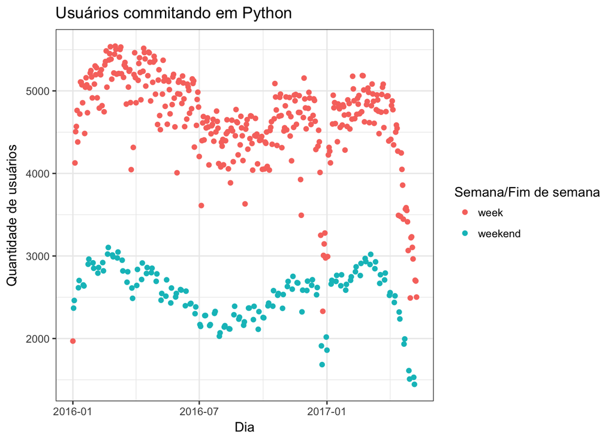

```r
py_or_js %>% filter(file_extension=="py") %>%
    ggplot(aes(x=date, y=users)) +
    geom_point(aes(colour=wowe)) +
    labs(title="Usuários commitando em Python", x="Dia", y="Quantidade de usuários", colour="Semana/Fim de semana")
```

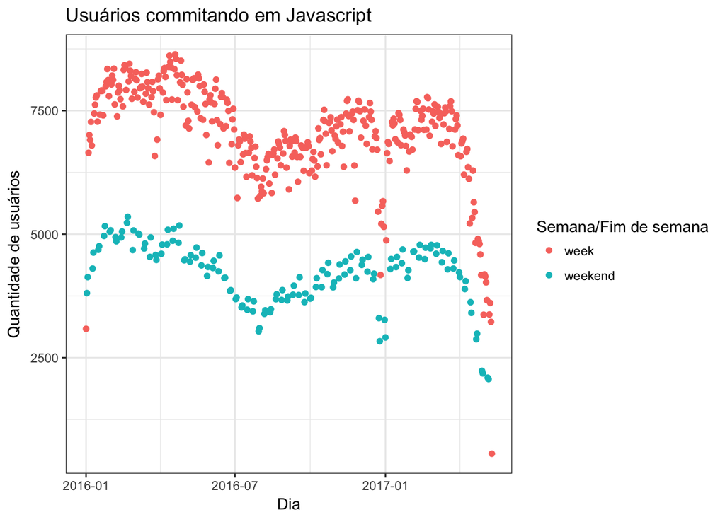

```r
py_or_js %>% filter(file_extension=="js") %>%
    ggplot(aes(x=date, y=users)) +
    geom_point(aes(colour=wowe)) +
    labs(title="Usuários commitando em Javascript", x="Dia", y="Quantidade de usuários", colour="Semana/Fim de semana")
```

Com esses passos já se tem o necessário para começar o processo de amostragem.

### Amostragem

Como dito no ínicio, o conjunto de dados analisado é uma amostra de dados de commits no github, não se tem acesso a todo o conjunto de dados de commits (população). Para que se possa inferir, com algum grau de confiança, que a amostra tem alguma representatividade sobre o conjunto de dados é preciso encontrar a distribuição amostral de alguma estatística dentro da amostra, nesse caso a mediana.

**A distribuição amostral é a distribuição de probabilidades de uma estatística baseada em dados de uma amostra leatória. Permite quantificar quão longe da estatística da população está a estatítica da amostra.**

Para estimar a distribuição amostral vai se utilizar uma técinica chamada *bootstrapping*, ela consiste na utilização da amostra como substituta da população. Com a realização de amostragem através de reamostragem da amostra, ou seja, serão criadas várias amostras “falsas” a partir da combinação com reposição da amostra original.

### Há uma diferença significativa na sua popularidade da linguagem durante a semana e durante o fim de semana? Essa diferença é grande?

#### Python

```r
set.seed(1)
py <- py_or_js %>% filter(file_extension == "py")

py.week <- py %>% filter(wowe=="week")
py.weekend <- py %>% filter(wowe=="weekend")

reps = 5000

median.py.week = bootstrap(py.week,
                        median(users),
                        R = reps) %>%
    CI.percentile(probs = c(.025, .975))
median.py.week
```

```
##                 2.5%  97.5%
## median(users) 4668.5 4791.5
```

```r
median.py.weekend = bootstrap(py.weekend, median(users), R = reps) %>%
    CI.percentile(probs = c(.025, .975))
median.py.weekend
```

```
##                 2.5% 97.5%
## median(users) 2520.5  2644
```

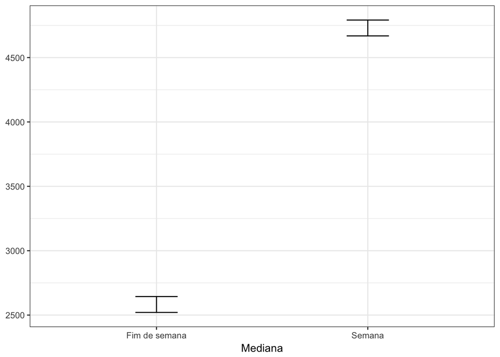

```r
df = data.frame(rbind(median.py.week,
                      median.py.weekend))
df$Mediana = c("Semana", "Fim de semana")

df %>%
  ggplot(aes(x = Mediana, ymin = X2.5., ymax = X97.5.)) +
  geom_errorbar(width = .2)
```

Observando a diferença entre os valores de medianda de usuários commitando em Python durante a semana e no fim de semana se pode inferir que a popularidade da linguagem é maior durante a semana.

#### Javascript

```r
set.seed(1)
js <- py_or_js %>% filter(file_extension == "js")

js.week <- js %>% filter(wowe=="week")
js.weekend <- js %>% filter(wowe=="weekend")

reps = 5000

median.js.week = bootstrap(js.week,
                        median(users),
                        R = reps) %>%
    CI.percentile(probs = c(.025, .975))
median.js.week
```

```
##               2.5% 97.5%
## median(users) 7072  7310
```

```r
median.js.weekend = bootstrap(js.weekend, median(users), R = reps) %>%
    CI.percentile(probs = c(.025, .975))
median.js.weekend
```

```
##                 2.5% 97.5%
## median(users) 4169.5  4450
```

Os valores observados acima são as distribuições amostrais da mediana da quantidade de usuários fazendo commits em Javascript durante a semana e durante o fim de semana, respectivamente. Os valores mostram que existe 95% de confiança de que a mediana do número usuários que fazem commits em Javascript da população está entre 7072 e 7310, durante a semana e entre 4169.5 e 4450 durante o fim de semana. No gráfico abaixo se vê o comportamento dos valores.

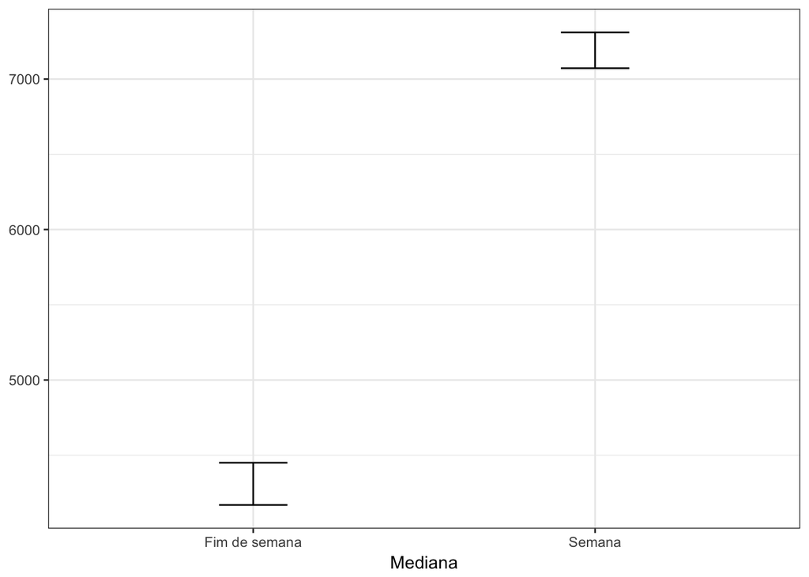

```r
df = data.frame(rbind(median.js.week,
                      median.js.weekend))
df$Mediana = c("Semana", "Fim de semana")

df %>%
  ggplot(aes(x = Mediana, ymin = X2.5., ymax = X97.5.)) +
  geom_errorbar(width = .2)
```

Observando a diferença entre os valores de medianda de usuários commitando em Javascript durante a semana e no fim de semana se pode inferir que a popularidade da linguagem é maior durante a semana. Também é possível ver que globalmente existem mais usuários commitando em Javascript do que em Python, seja durante a semana, seja durante o fim de semana.

### Existe uma diferença significativa entre as duas linguagens na sua variação de popularidade nos finais de semana?

Para responder essa pergunta é preciso quantificar a popularidade das linguagens, nesse caso isso significa criar um índice para representar a diferença de usuários durante o fim de semana.

No gráfico abaixo se pode observar as distribuições amostrais das diferenças entre número de usuários fazendo commits durante a semana e durante o fim de semana, tanto para Python quando para Javascript.

```r
set.seed(1)
b = bootstrap2(data = py.weekend$users,
               data2 = py.week$users,
               median)
medians.py.diff = CI.percentile(b, probs = c(.025, .975))
medians.py.diff
```

```
##                     2.5%   97.5%
## median: data-data2 -2236 -2062.5
```

```r
b2 = bootstrap2(data = js.weekend$users,
               data2 = js.week$users,
               median)
medians.js.diff = CI.percentile(b2, probs = c(.025, .975))
medians.js.diff
```

```
##                     2.5%   97.5%
## median: data-data2 -3052 -2678.5
```

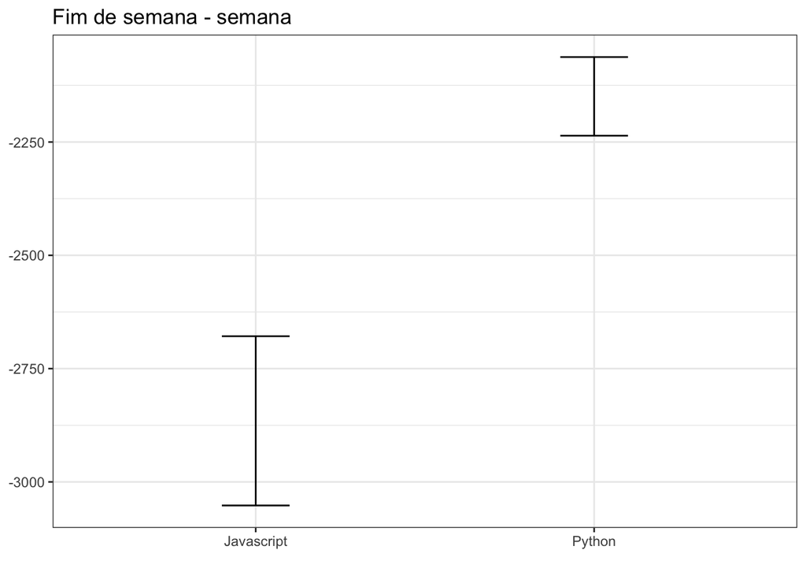

```r
data.frame(rbind(medians.py.diff, medians.js.diff)) %>%
  ggplot(aes(x = c("Python", "Javascript"), ymin = X2.5., ymax = X97.5.)) +
  geom_errorbar(width = .2) +
  labs(title="Fim de semana - semana", x="")
```

O gráfico abaixo mostra os resultados das distribuições amostrais das medianas dos índices de diferença entre usuários commitando no fim de semana e durante a semana. Esses dados foram calculados com o uso de reamostragem das medianas de uso durante semana e fim de semana e reamostragem das diferenças obtidas na reamostragem anterior. O cálculo da diferença se dá dividindo a quantidade mediana de usuários commitando durante o fim de semana pela quantidade de usuário commitando durante a semana.

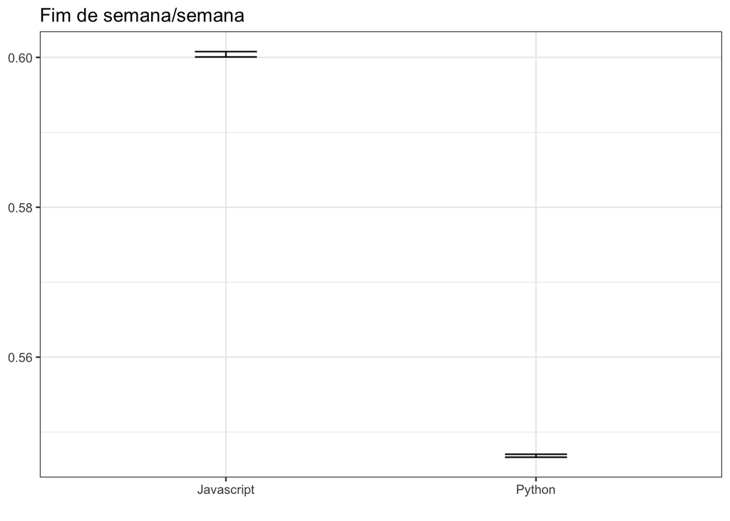

```r
set.seed(1)

medians.py.diffs = bootstrap(reamostragem.py.medians, median(weekend_prob), R = reps) %>%
    CI.percentile(probs = c(.025, .975))

medians.js.diffs = bootstrap(reamostragem.js.medians, median(weekend_prob), R = reps) %>%
    CI.percentile(probs = c(.025, .975))

data.frame(rbind(medians.py.diffs, medians.js.diffs)) %>%
  ggplot(aes(x = c("Python", "Javascript"), ymin = X2.5., ymax = X97.5.)) +
  geom_errorbar(width = .2) +
  labs(title="Fim de semana/semana", x="")
```